# IODS course project

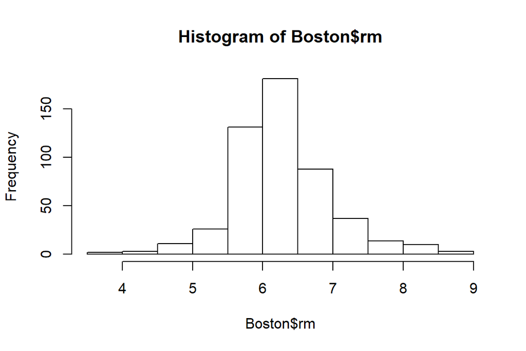

```r
hist(Boston$rm)
```

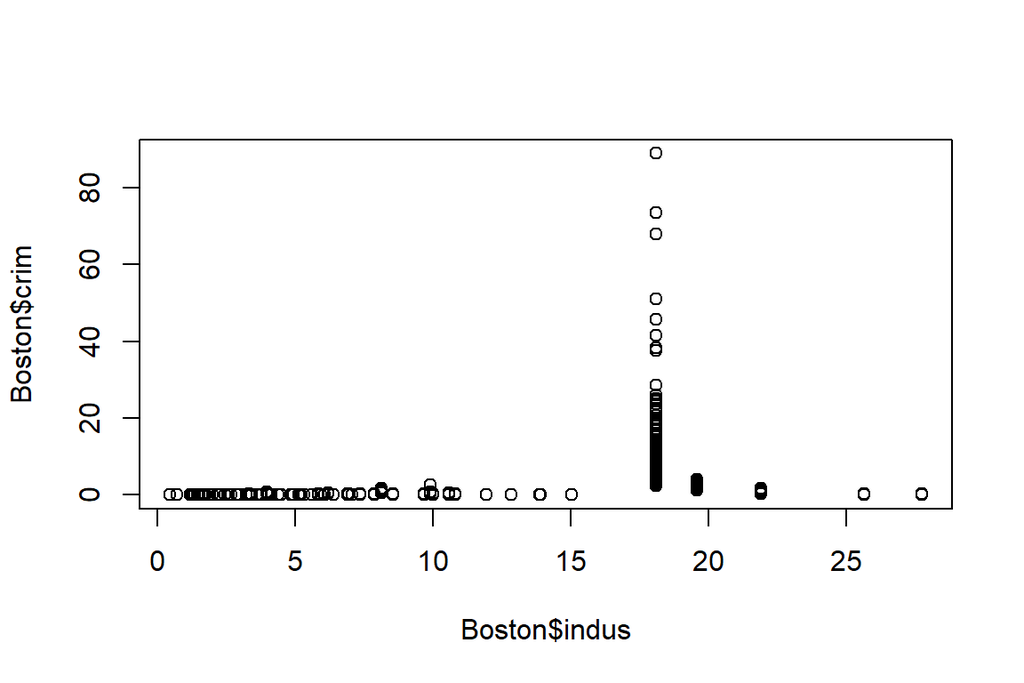

```r
plot(Boston$indus, Boston$crim)
```

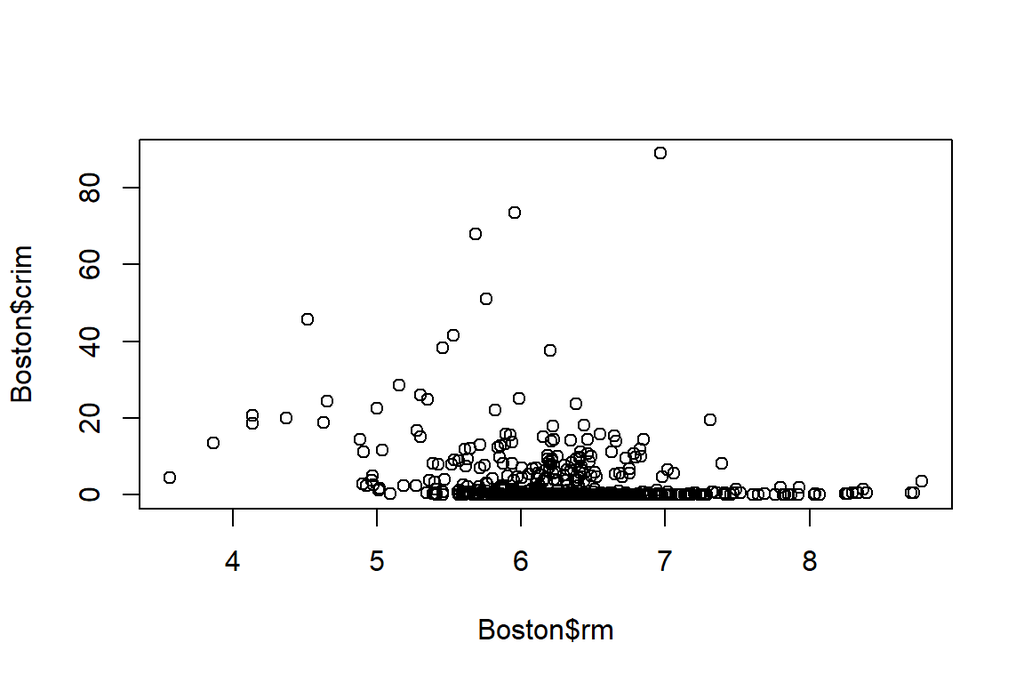

```r
plot(Boston$rm, Boston$crim)
```

According to pairs -analysis there seems to be some interesting relationships worth a closer study.Per capita crime rates seem to follow a poisson distribution. Average number of rooms per dwelling seems to be normally distributed. Proportion of non-retail business acres per town is not. There does not seem to be any clear relationship between the proportion of non-retail business acres or average number of rooms per dwelling and per capita crime rate.

## Exercise 4:

Standardizing the dataset, creating categorical variable and dividing the data to training and test sets…

```r
boston_scaled<-scale(Boston)
summary(boston_scaled) #Now the mean of the variables is 0 and standard deviation is 1.
```

```
##       crim                 zn               indus
##  Min.   :-0.419367   Min.   :-0.48724   Min.   :-1.5563
##  1st Qu.:-0.410563   1st Qu.:-0.48724   1st Qu.:-0.8668
##  Median :-0.390280   Median :-0.48724   Median :-0.2109
##  Mean   : 0.000000   Mean   : 0.00000   Mean   : 0.0000
##  3rd Qu.: 0.007389   3rd Qu.: 0.04872   3rd Qu.: 1.0150
##  Max.   : 9.924110   Max.   : 3.80047   Max.   : 2.4202
##       chas              nox                rm               age
##  Min.   :-0.2723   Min.   :-1.4644   Min.   :-3.8764   Min.   :-2.3331
##  1st Qu.:-0.2723   1st Qu.:-0.9121   1st Qu.:-0.5681   1st Qu.:-0.8366
##  Median :-0.2723   Median :-0.1441   Median :-0.1084   Median : 0.3171
##  Mean   : 0.0000   Mean   : 0.0000   Mean   : 0.0000   Mean   : 0.0000
##  3rd Qu.:-0.2723   3rd Qu.: 0.5981   3rd Qu.: 0.4823   3rd Qu.: 0.9059
##  Max.   : 3.6648   Max.   : 2.7296   Max.   : 3.5515   Max.   : 1.1164
##       dis               rad               tax             ptratio
##  Min.   :-1.2658   Min.   :-0.9819   Min.   :-1.3127   Min.   :-2.7047
##  1st Qu.:-0.8049   1st Qu.:-0.6373   1st Qu.:-0.7668   1st Qu.:-0.4876
##  Median :-0.2790   Median :-0.5225   Median :-0.4642   Median : 0.2746
##  Mean   : 0.0000   Mean   : 0.0000   Mean   : 0.0000   Mean   : 0.0000
##  3rd Qu.: 0.6617   3rd Qu.: 1.6596   3rd Qu.: 1.5294   3rd Qu.: 0.8058
##  Max.   : 3.9566   Max.   : 1.6596   Max.   : 1.7964   Max.   : 1.6372
##      black             lstat              medv
##  Min.   :-3.9033   Min.   :-1.5296   Min.   :-1.9063
##  1st Qu.: 0.2049   1st Qu.:-0.7986   1st Qu.:-0.5989
##  Median : 0.3808   Median :-0.1811   Median :-0.1449
##  Mean   : 0.0000   Mean   : 0.0000   Mean   : 0.0000
##  3rd Qu.: 0.4332   3rd Qu.: 0.6024   3rd Qu.: 0.2683
##  Max.   : 0.4406   Max.   : 3.5453   Max.   : 2.9865
```

```r
class(boston_scaled)
```

```
## [1] "matrix"
```

```r
boston_scaled<-as.data.frame(boston_scaled)
```

```r
summary(boston_scaled$crim)
```

```
##      Min.   1st Qu.    Median      Mean   3rd Qu.      Max.
## -0.419367 -0.410563 -0.390280  0.000000  0.007389  9.924110
```

```r
bins<-quantile(boston_scaled$crim)
crime<-cut(boston_scaled$crim,breaks = bins,include.lowest = TRUE,labels = c("low","med_low","med_high", "high"))
table(crime)
```

```
## crime
##      low  med_low med_high     high
##      127      126      126      127
```

```r
library(dplyr)
boston_scaled<-select(boston_scaled, -crim)
boston_scaled<-data.frame(boston_scaled,crime)
```

```r
n<-nrow(boston_scaled)
ind<-sample(n,size = n*0.8)
train<-boston_scaled[ind, ]
test<-boston_scaled[-ind, ]
```

## Exercise 5:

Fitting linear discriminant analysis on the train set…

```r
lda.fit<-lda(crime~.,data=train)
lda.fit
```

```
## Call:
## lda(crime ~ ., data = train)
##
## Prior probabilities of groups:
##       low   med_low  med_high      high
## 0.2549505 0.2524752 0.2376238 0.2549505
##
## Group means:
##                   zn      indus        chas        nox         rm
## low       0.97266387 -0.9781379 -0.08120770 -0.9098724  0.4682446
## med_low  -0.05426518 -0.3500526 -0.04073494 -0.5693966 -0.1077443
## med_high -0.41577829  0.2781824  0.26081992  0.4350200  0.0711788
## high     -0.48724019  1.0149946 -0.04298342  1.0191035 -0.3225574
##                 age        dis        rad        tax     ptratio
## low      -0.8976254  0.9179912 -0.6930819 -0.7254561 -0.51805138
## med_low  -0.3533525  0.3948677 -0.5337439 -0.4760219 -0.09538992
## med_high  0.4976924 -0.4331298 -0.3837113 -0.2441207 -0.25083014
## high      0.8387741 -0.8644152  1.6596029  1.5294129  0.80577843
##                black       lstat        medv
## low       0.38023436 -0.78773950  0.55971708
## med_low   0.31657911 -0.13211697  0.01945812
## med_high  0.02846465  0.03317949  0.13189228
## high     -0.87053624  0.89260136 -0.71126130
##
## Coefficients of linear discriminants:
##                 LD1         LD2         LD3
## zn       0.11656229  0.50514792 -0.99138636
## indus    0.02225034 -0.45429629  0.33844094
## chas    -0.05916755 -0.06039960  0.04702004
## nox      0.27823969 -0.72128501 -1.22692372
## rm      -0.04428236 -0.04706283 -0.12950809
## age      0.38883184 -0.38923765 -0.21554124
## dis     -0.11704936 -0.16307398  0.25580761
## rad      3.16217424  0.90628966 -0.02287028
## tax      0.04902156  0.19556188  0.40082873
## ptratio  0.15192221 -0.01553976 -0.23004105
## black   -0.16222988  0.01558973  0.15393164
## lstat    0.16518822 -0.08451657  0.49665048
## medv     0.14441734 -0.28880990 -0.12311691
##
## Proportion of trace:
##    LD1    LD2    LD3
## 0.9487 0.0406 0.0108
```

Biplot…

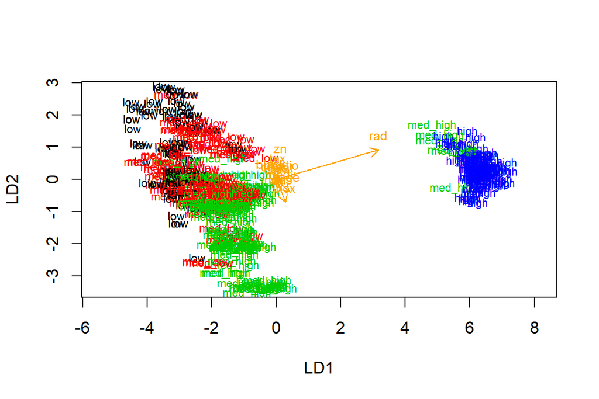

```r
lda.arrows<-function(x,myscale=1,arrow_heads=0.1, color="orange",tex=0.75,choices=c(1,2)){
  heads<-coef(x)
  arrows(x0=0,y0=0,
         x1=myscale*heads[,choices[1]],
         y1=myscale*heads[,choices[2]],col = color, length = arrow_heads)
  text(myscale*heads[,choices],labels=rownames(heads),
       cex = tex,col = color,pos = 3)
}
classes=as.numeric(train$crime)
plot(lda.fit,dimen=2,col=classes,pch=classes)
lda.arrows(lda.fit,myscale = 1)
```

## Exercise 6:

Predicting the classes with the LDA model…

```r
correct_classes<-test$crime #Saving the crime categories from the test set
test<-select(test, -crime) # Removing crime -variable from test-data
lda.pred<-predict(lda.fit,newdata=test)
table(correct=correct_classes,predicted=lda.pred$class)
```

```
##           predicted
## correct    low med_low med_high high
##   low       12       9        3    0
##   med_low    1      15        8    0
##   med_high   1      13       16    0
##   high       0       0        1   23
```

## Exercise 7:

Let’s reload the dataset and standardize it.

```r
library(MASS)
data(Boston)
head(Boston)
```

```
##      crim zn indus chas   nox    rm  age    dis rad tax ptratio  black
## 1 0.00632 18  2.31    0 0.538 6.575 65.2 4.0900   1 296    15.3 396.90
## 2 0.02731  0  7.07    0 0.469 6.421 78.9 4.9671   2 242    17.8 396.90
## 3 0.02729  0  7.07    0 0.469 7.185 61.1 4.9671   2 242    17.8 392.83
## 4 0.03237  0  2.18    0 0.458 6.998 45.8 6.0622   3 222    18.7 394.63
## 5 0.06905  0  2.18    0 0.458 7.147 54.2 6.0622   3 222    18.7 396.90
## 6 0.02985  0  2.18    0 0.458 6.430 58.7 6.0622   3 222    18.7 394.12
##   lstat medv
## 1  4.98 24.0
## 2  9.14 21.6
## 3  4.03 34.7
## 4  2.94 33.4
## 5  5.33 36.2
## 6  5.21 28.7
```

```r
boston_scaled2<-scale(Boston)
boston_scaled2<-as.data.frame(boston_scaled2)
head(boston_scaled2)
```

```
##         crim         zn      indus       chas        nox        rm
## 1 -0.4193669  0.2845483 -1.2866362 -0.2723291 -0.1440749 0.4132629
## 2 -0.4169267 -0.4872402 -0.5927944 -0.2723291 -0.7395304 0.1940824
## 3 -0.4169290 -0.4872402 -0.5927944 -0.2723291 -0.7395304 1.2814456
## 4 -0.4163384 -0.4872402 -1.3055857 -0.2723291 -0.8344581 1.0152978
## 5 -0.4120741 -0.4872402 -1.3055857 -0.2723291 -0.8344581 1.2273620
## 6 -0.4166314 -0.4872402 -1.3055857 -0.2723291 -0.8344581 0.2068916
##          age      dis        rad        tax    ptratio     black
## 1 -0.1198948 0.140075 -0.9818712 -0.6659492 -1.4575580 0.4406159
## 2  0.3668034 0.556609 -0.8670245 -0.9863534 -0.3027945 0.4406159
## 3 -0.2655490 0.556609 -0.8670245 -0.9863534 -0.3027945 0.3960351
## 4 -0.8090878 1.076671 -0.7521778 -1.1050216  0.1129203 0.4157514
## 5 -0.5106743 1.076671 -0.7521778 -1.1050216  0.1129203 0.4406159
## 6 -0.3508100 1.076671 -0.7521778 -1.1050216  0.1129203 0.4101651
##        lstat       medv
## 1 -1.0744990  0.1595278
## 2 -0.4919525 -0.1014239
## 3 -1.2075324  1.3229375
## 4 -1.3601708  1.1815886
## 5 -1.0254866  1.4860323
## 6 -1.0422909  0.6705582
```

Then let’s Calculate the distances between the observations…

```r
dist_bost<-dist(boston_scaled2)
head(dist_bost)
```

```
## [1] 1.935677 2.280929 2.574117 2.690602 2.240723 1.784194
```

Then let’s run k-means algorithm on the dataset

```r
set.seed(123)
km_fit<-kmeans(boston_scaled2,3)
km_fit
```

```
## K-means clustering with 3 clusters of sizes 202, 142, 162
##
## Cluster means:
##         crim         zn        indus        chas         nox         rm
## 1 -0.3549295 -0.4039269  0.009294842  0.11748284  0.01531993 -0.2547135
## 2  0.9693718 -0.4872402  1.074440092 -0.02279455  1.04197430 -0.4146077
## 3 -0.4071299  0.9307491 -0.953383032 -0.12651054 -0.93243813  0.6810272
##          age        dis        rad        tax     ptratio      black
## 1  0.3096462 -0.2267757 -0.5759279 -0.4964651 -0.09219308  0.2473725
## 2  0.7666895 -0.8346743  1.5010821  1.4852884  0.73584205 -0.7605477
## 3 -1.0581385  1.0143978 -0.5976310 -0.6828704 -0.53004055  0.3582008
##         lstat       medv
## 1  0.09168925 -0.1052456
## 2  0.85963373 -0.6874933
## 3 -0.86783467  0.7338497
```

[output cut: 70 more lines]

Then lets see what is the optimal number of clusters.

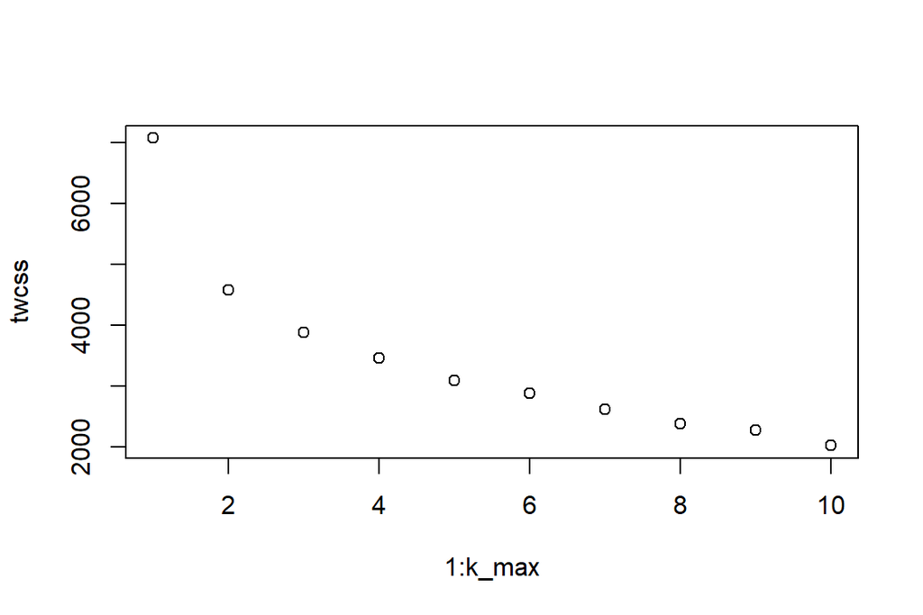

```r
k_max<-10
twcss<-sapply(1:k_max,function(k){kmeans(boston_scaled2,k)$tot.withinss})
plot(x=1:k_max,y=twcss)
```

The elbow method is not giving a very clear answer, but let’s go with k=4…

```r
km_fit2<-kmeans(boston_scaled2,4)
km_fit2
```

```
## K-means clustering with 4 clusters of sizes 134, 85, 148, 139
##
## Cluster means:
##         crim         zn      indus        chas        nox         rm
## 1  1.0414695 -0.4872402  1.0359674 -0.03727831  1.0077445 -0.3899069
## 2 -0.3913244  1.2858555 -0.9871833  0.09822154 -0.6939651  1.4412012
## 3 -0.4042497  0.1296981 -0.7245936 -0.27232907 -0.8172043 -0.0927410
## 4 -0.3342833 -0.4546967  0.3764806  0.26583571  0.3229892 -0.4066828
##          age        dis        rad        tax     ptratio      black
## 1  0.7586435 -0.8253047  1.6253203  1.5333981  0.80508902 -0.7441911
## 2 -0.6808202  0.5260255 -0.5846367 -0.7000837 -1.13313736  0.3582287
## 3 -0.8763221  0.8802002 -0.5915476 -0.6903644 -0.09431288  0.3569895
## 4  0.6180371 -0.4632444 -0.5794946 -0.3150669  0.01721621  0.1182570
##        lstat       medv
## 1  0.8500550 -0.6807757
```

[output cut: 73 more lines]

Then let’s Visualize the clusters

[figure not shown]

```r
pairs(boston_scaled2,col=km_fit2$cluster)
```

Then lets take a closer look at some of the variables and the clusters.

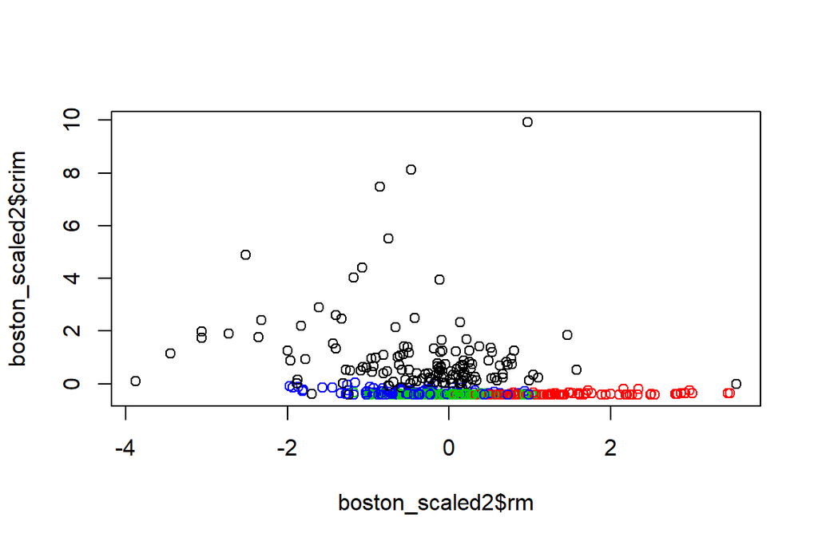

```r
plot(boston_scaled2$rm,boston_scaled2$crim, col=km_fit2$cluster)
```

## Bonus

```r
boston_scaled3<-scale(Boston)
head(boston_scaled3)
```

```
##         crim         zn      indus       chas        nox        rm
## 1 -0.4193669  0.2845483 -1.2866362 -0.2723291 -0.1440749 0.4132629
## 2 -0.4169267 -0.4872402 -0.5927944 -0.2723291 -0.7395304 0.1940824
## 3 -0.4169290 -0.4872402 -0.5927944 -0.2723291 -0.7395304 1.2814456
## 4 -0.4163384 -0.4872402 -1.3055857 -0.2723291 -0.8344581 1.0152978
## 5 -0.4120741 -0.4872402 -1.3055857 -0.2723291 -0.8344581 1.2273620
## 6 -0.4166314 -0.4872402 -1.3055857 -0.2723291 -0.8344581 0.2068916
##          age      dis        rad        tax    ptratio     black
## 1 -0.1198948 0.140075 -0.9818712 -0.6659492 -1.4575580 0.4406159
## 2  0.3668034 0.556609 -0.8670245 -0.9863534 -0.3027945 0.4406159
## 3 -0.2655490 0.556609 -0.8670245 -0.9863534 -0.3027945 0.3960351
## 4 -0.8090878 1.076671 -0.7521778 -1.1050216  0.1129203 0.4157514
## 5 -0.5106743 1.076671 -0.7521778 -1.1050216  0.1129203 0.4406159
## 6 -0.3508100 1.076671 -0.7521778 -1.1050216  0.1129203 0.4101651
##        lstat       medv
## 1 -1.0744990  0.1595278
## 2 -0.4919525 -0.1014239
## 3 -1.2075324  1.3229375
## 4 -1.3601708  1.1815886
## 5 -1.0254866  1.4860323
## 6 -1.0422909  0.6705582
```

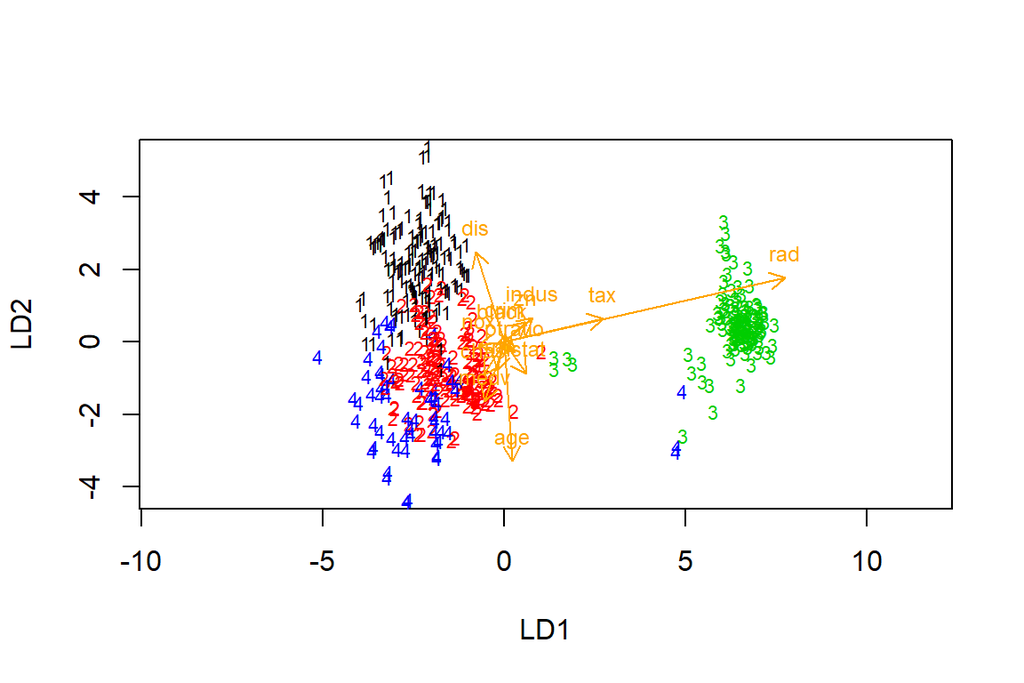

```r
boston_scaled3<-as.data.frame(boston_scaled3)
km.fit3<-kmeans(boston_scaled3,4)
lda.fit3<-lda(km.fit3$cluster~.,boston_scaled3)
classes<-as.numeric(km.fit3$cluster)

lda.arrows<-function(x,myscale=1,arrow_heads=0.1, color="orange",tex=0.75,choices=c(1,2)){
  heads<-coef(x)
  arrows(x0=0,y0=0,
         x1=myscale*heads[,choices[1]],
         y1=myscale*heads[,choices[2]],col = color, length = arrow_heads)
  text(myscale*heads[,choices],labels=rownames(heads),
       cex = tex,col = color,pos = 3)
}
plot(lda.fit3,dimen=2,col=classes,pch=classes)
lda.arrows(lda.fit3,myscale = 3)
```

It seems that variables that are the most influencial linear separators for the clusters are rad (index of accessibility to radial highways), age (proportion of owner-occupied units build prior to 1940) and dis (weighted mean of distaces to five Boston employment centres).

# Chapter 5: Dimensionality reduction techniques

## Exercise 1:

First let’s load the ‘human’ data into R and explore the structure and the dimensions of the data and describe the dataset briefly.

```r
human_<-read.table("http://s3.amazonaws.com/assets.datacamp.com/production/course_2218/datasets/human2.txt", header=TRUE, sep=",")
head(human_)
```

```
##               Edu2.FM   Labo.FM Edu.Exp Life.Exp   GNI Mat.Mor Ado.Birth
## Norway      1.0072389 0.8908297    17.5     81.6 64992       4       7.8
## Australia   0.9968288 0.8189415    20.2     82.4 42261       6      12.1
## Switzerland 0.9834369 0.8251001    15.8     83.0 56431       6       1.9
## Denmark     0.9886128 0.8840361    18.7     80.2 44025       5       5.1
## Netherlands 0.9690608 0.8286119    17.9     81.6 45435       6       6.2
## Germany     0.9927835 0.8072289    16.5     80.9 43919       7       3.8
##             Parli.F
## Norway         39.6
## Australia      30.5
## Switzerland    28.5
## Denmark        38.0
## Netherlands    36.9
## Germany        36.9
```

```r
str(human_)
```

```
## 'data.frame':    155 obs. of  8 variables:
##  $ Edu2.FM  : num  1.007 0.997 0.983 0.989 0.969 ...
##  $ Labo.FM  : num  0.891 0.819 0.825 0.884 0.829 ...
##  $ Edu.Exp  : num  17.5 20.2 15.8 18.7 17.9 16.5 18.6 16.5 15.9 19.2 ...
##  $ Life.Exp : num  81.6 82.4 83 80.2 81.6 80.9 80.9 79.1 82 81.8 ...
##  $ GNI      : int  64992 42261 56431 44025 45435 43919 39568 52947 42155 32689 ...
##  $ Mat.Mor  : int  4 6 6 5 6 7 9 28 11 8 ...
##  $ Ado.Birth: num  7.8 12.1 1.9 5.1 6.2 3.8 8.2 31 14.5 25.3 ...
##  $ Parli.F  : num  39.6 30.5 28.5 38 36.9 36.9 19.9 19.4 28.2 31.4 ...
```

```r
dim(human_)
```

```
## [1] 155   8
```

The data has 155 observations (countries) and 8 variables. Variables are related to education, labor participation, life expectancy, gross national income etc.